# Distribución binomial

Téllez Gerardo Rubén

1/2/2022

## Distribución Binomial

Si $X$ es variable aleatoria que mide “número de éxitos” (ya no sólo si hay éxito o fracaso) y se realizan $n$ ensayos de Bernoulli independientes entre sí, diremos que $X$ se distribuye como una Binomial con parámetros $n$ y $p$

$$X \sim B(n, p)$$

donde $p$ es la probabilidad de éxito y $q = 1 - p$ es la probabilidad de fracaso.

La ordenación de los $k$ éxitos es lo que proporciona esta función de densidad

- El dominio de $X$ será $D_X = {0,1,2, \dots , n}$
- La función de densidad vendrá dada por:

$$f(k) = nCk \times p^k \times (1-p)^{n-k} = {n \choose k} p^k (1-p)^{n-k}$$
+ La función de distribución o acumulada:

$$F(X) = \Bigg \{ \begin{matrix} 0 & si\ k < 0 \\ \sum_{k_0}^{x} f(k) & si\ 0 \le x<n \\ 1 & si\ x \ge n \end{matrix}$$

- Esperanza $E(X) = np$
- Varianza $Var(X) = npq$

**Atención**: Fíjate que la distribución de Bernoulli es un caso particular de la Binomial. Basta tomar $n = 1$ y tendremos que $X \sim Be(p)$ y $X \sim B(1,p)$ son equivalentes.

## Esperanza

Siendo:

$$E(X) = \sum_{x \in Dx} x \times f(x)$$

## Esperanza

$$E(X) = \sum_{x=0}^{n} x \times {n \choose x} p^x (1 - p)^{n-x}$$

Cada evento, por la probabilidad de que aparezca.

$$E(X) = \sum_{x=0}^{n} x \times \frac{n!}{x!(n-x)!} p^x (1 - p)^{n-x}$$

$$E(X) = \sum_{x=0}^{n} x \times \frac{n}{x} {n-1 \choose x-1} p^x (1 - p)^{n-x}$$
$$E(X) = n \times \sum_{x=0}^{n} {n-1 \choose x-1} p^x (1 - p)^{n-x}$$

$$Si\ m = x-1$$

$$E(X) = n \times \sum_{m=0}^{n-1} {n-1 \choose m} p^{m + 1} (1 - p)^{n-m+1}$$

$$E(X) = n \times \sum_{m=0}^{n-1} {n-1 \choose m} p^{m + 1} (1 - p)^{n-m+1}$$

$$E(X) = np \times \sum_{m=0}^{n-1} {n-1 \choose m} p^{m} (1 - p)^{(n-1)-k}$$

$$E(X) = np(p+1-p)^{n-1}=np$$

## Ejemplo

Suponiendo que la probabilidad de éxito es del 10% y de fracaso del 90% (éxito de los comercios de Herbalife) ¿Cuál es la probabilidad de que 5 de 100 negocios tengan éxito?

$$f(5) = p(X = 5) = {100 \choose 5} 0.1^{5}(0.9)^{95} = 0.0338658$$

¿Cuál es la probabilidad desde 0 hasta 3 negocios de 100 tengan éxito?

```r
pt = 0
for(n in 0:3){
  pt = pt + (choose(100, n) * 0.1^n * (0.9)^(100-n))
}

pt
```

```
## [1] 0.007836487
```

$$F(3) = p(X \le 3) = p(X=0) + p(X=1) + P(X=2) + P(X=3) = \sum_{x \in \{0, 1,2,3\}} {100 \choose x} \times 0.1^x \times 0.9^{100 - x} = 0.007836487$$

¿Cuál es la probabilidad de que 10 o más negocios hasta los 100 tengan éxito?

$$p(X \ge 10) = p(X = 10) \dots p(X = 100) = 0.5487098$$

```r
pt = 0
for(n in 10:100){
  pt = pt + (choose(100, n) * 0.1^n * (0.9)^(100-n))
}

pt
```

```
## [1] 0.5487098
```

## Ejemplo Distribución de probabilidad acumualda (k o menos tengan éxito)

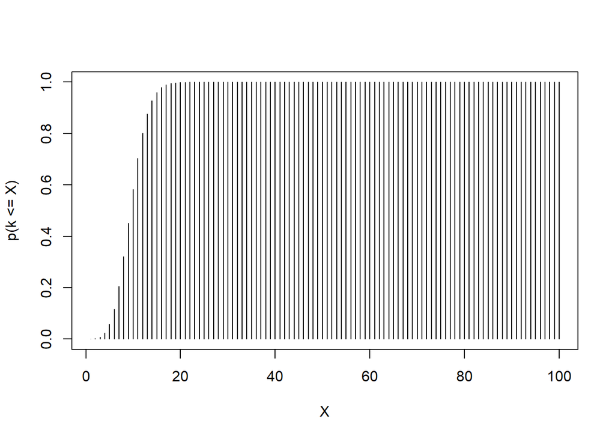

```r
pt = 0
fpt = c()
for(n in 1:100){
  pt = pt + (choose(100, n) * 0.1^n * (0.9)^(100-n))
  fpt = c(fpt, pt)
}
plot(x=1:100, y=fpt, xlab="X", ylab = "p(k <= X)", type="h")
```

```r
pt
```

```
## [1] 0.9999734
```

Usando el paquete stats

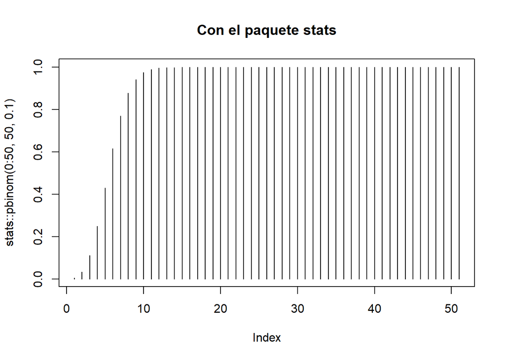

```r
plot(stats::pbinom(0:50, 50, 0.1), type="h", main="Con el paquete stats")
```

## Ejemplo Distribución de probabilidad de la variable aleatoria

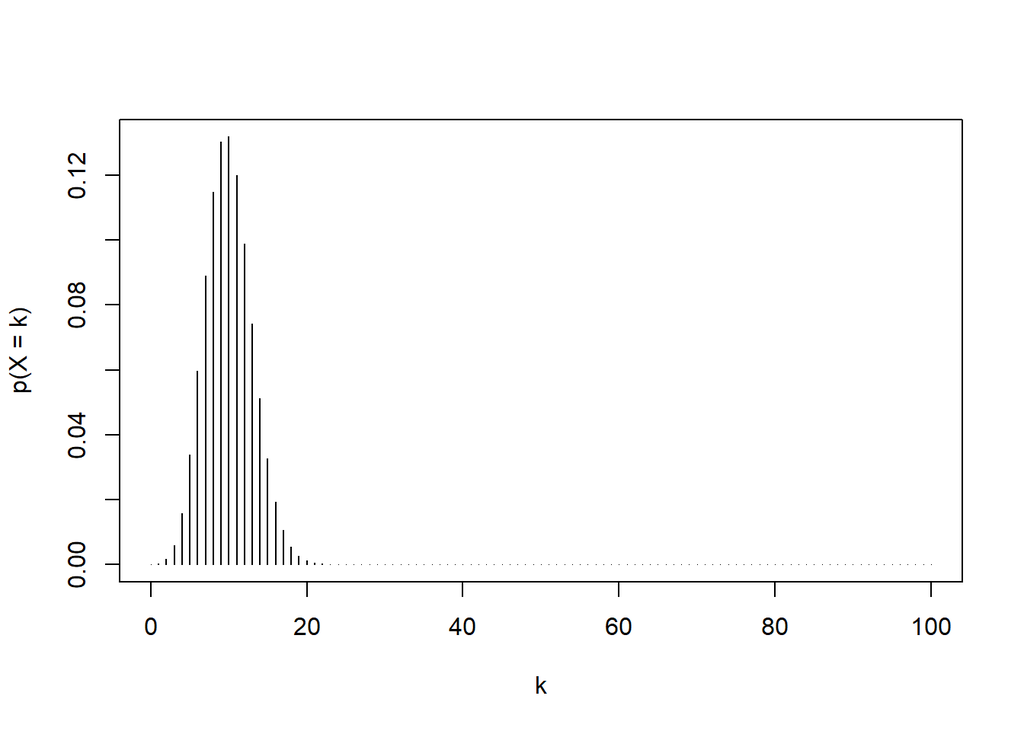

```r
p = 0
fp = c()
for(n in 0:100){
  p = (choose(100, n) * 0.1^n * (0.9)^(100-n))
  fp = c(fp, p)
}

plot(x = 0:100, y = fp, type = "h", ylab="p(X = k)", xlab="k")
```

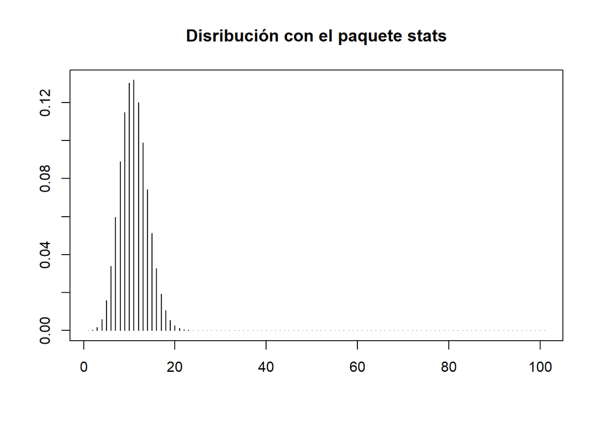

```r
plot(stats::dbinom(0:100, 100, 0.1), type ="h",ylab="",xlab="", main="Disribución con el paquete stats")
```

## Distribución binomial

Atención. Fijaos que la distribución de Bernoilli es un caso particular de la Binomial $n=1$ y tendremos que $X \sim Be(p)$ y $X \sim B(1, p)$ son equivalentes.

## Función de probabilidad de una B(50, 0.5)

Suponiendo que el éxito sea sacar cara, en 50 lanzamientos de moneda, lo más probable es sacar 25 caras.

$$p(X = 25) = {50 \choose 25} \times 0.5^{25} \times 0.5^{25} = 0.1122752$$

```r
stats::dbinom(25, 50, 0.5)
```

```
## [1] 0.1122752
```

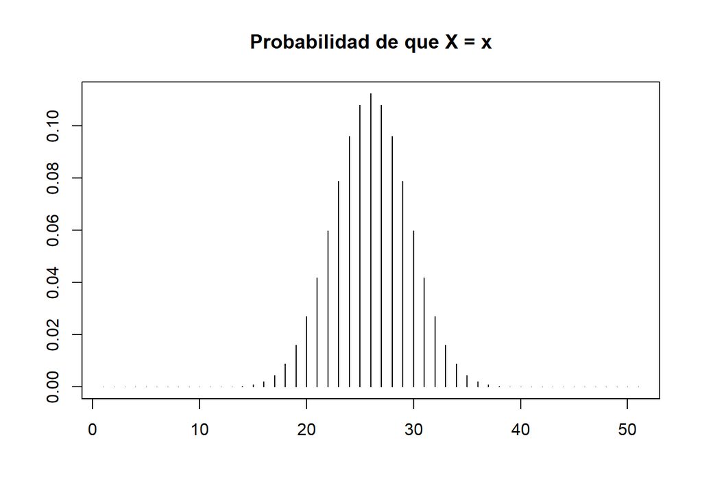

```r
n = 0:50
p = (choose(50, n) * 0.5^n * (0.5)^(50-n))
plot(p, xlab="",ylab="", type="h", main="Probabilidad de que X = x")
```

## Función de distribución de una probabilidad.

$$F(k) = P(X \le k) = P(X=0) + P(X=1) + P(X=2) + \dots + P(X=k) = \sum_{x =0}^{k} {100 \choose x} \times p^x \times q^{n - x}$$

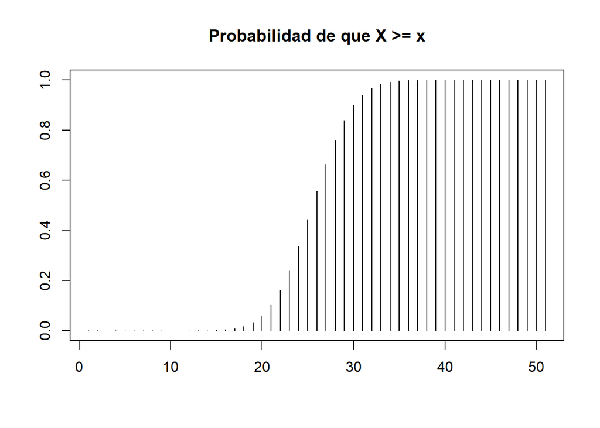

```r
n = 0:50
f = cumsum((choose(50, n) * 0.5^n * (0.5)^(50-n)))
plot(f,  xlab="",ylab="", type="h", main="Probabilidad de que X >= x")
```

## Código de la distribución binomial

El código de la distribución Binomial:

- En R tenemos las funciones de `stats`, `dbinom(x=exitos, size=intentos, prob=p.exito)` para obtener la probabilidad $P(X=x)$, `pbinom(q=max.exitos,size=intentos,prob=p.exito)` función de densidad $F(X) = P(X \le x)$, `qbinom(p=cuantil, size=intentos,prob=p.exito)` , `rbinom(n=muestras, size=intentos.hipotéticos, prob=p.exito)` obtener una muestra aleatoria de n tamaño.
- En Python tenemos las funciones del paquete `scipy.stats.binomial`: `pmf(k=exitos,n=intentos,p=p_exito)` para obtener la probabilidad $P(X=x)$, `cdf(k=max_exitos,n=intentos,p=p_exito)` función de densidad $F(X) = P(X \le x)$, `ppf(q,n,p)` cuantil q, `rvs(n=intentos,p=p_exito,size=tamaño)` muestra aleatoria

```r
stats::dbinom(25, 50, 0.5)
```

```
## [1] 0.1122752
```

```r
stats::pbinom(25, 50, 0.5)
```

```
## [1] 0.5561376
```

```r
stats::qbinom(0.25, 50, 0.5)
```

```
## [1] 23
```

```r
stats::rbinom(3, 50, 0.5)
```

```
## [1] 22 29 25
```

```python
from scipy import stats as st

print(st.binom.pmf(25, 50, 0.5)) #igual que stats::dbinom(25, 50, 0.5)
```

```
## 0.11227517265921609
```

```python
print(st.binom.cdf(25, 50, 0.5)) #igual que stats::pbinom(25, 50, 0.5)
```

```
## 0.5561375863296087
```

```python
print(st.binom.ppf(0.25,50, 0.5)) #igual que stats::qbinom(0.25, 50, 0.5)
```

```
## 23.0
```

```python
print(st.binom.rvs(n=50, p=0.5, size=3)) #igual que stats::rbinom(3, 50, 0.5)
```

```
## [26 24 27]
```

## Ejercicio

Sea $X = B(n = 30, p = 0.6)$

#### $$P(X = n)$$

```r
n = 30
p = 0.6
k = 0:n
dbe = dbinom(x = k, size = n, prob = p)
dbe
```

```
##  [1] 1.152922e-12 5.188147e-11 1.128422e-09 1.579791e-08 1.599538e-07
##  [6] 1.247640e-06 7.797748e-06 4.010270e-05 1.729429e-04 6.341240e-04
## [11] 1.997491e-03 5.447702e-03 1.293829e-02 2.687184e-02 4.894513e-02
## [16] 7.831221e-02 1.101265e-01 1.360387e-01 1.473752e-01 1.396186e-01
## [21] 1.151854e-01 8.227527e-02 5.048710e-02 2.634109e-02 1.152423e-02
## [26] 4.148722e-03 1.196747e-03 2.659437e-04 4.274096e-05 4.421478e-06
## [31] 2.210739e-07
```

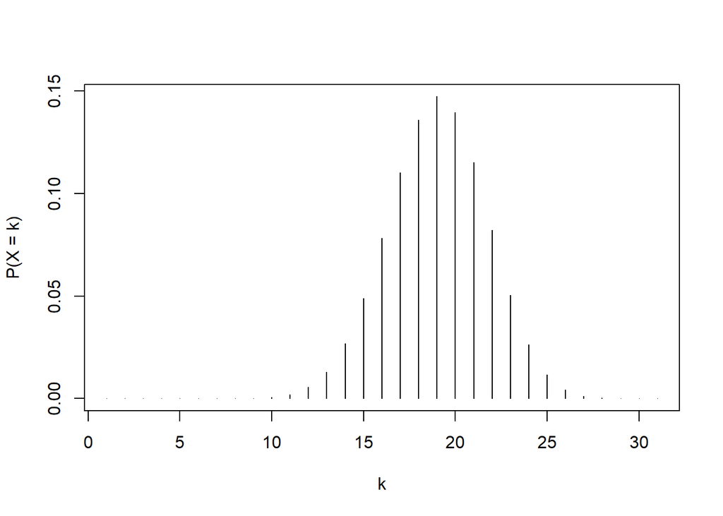

```r
plot(dbe, type="h", xlab="k", ylab="P(X = k)")
```

#### $$P =(X \le n)$$

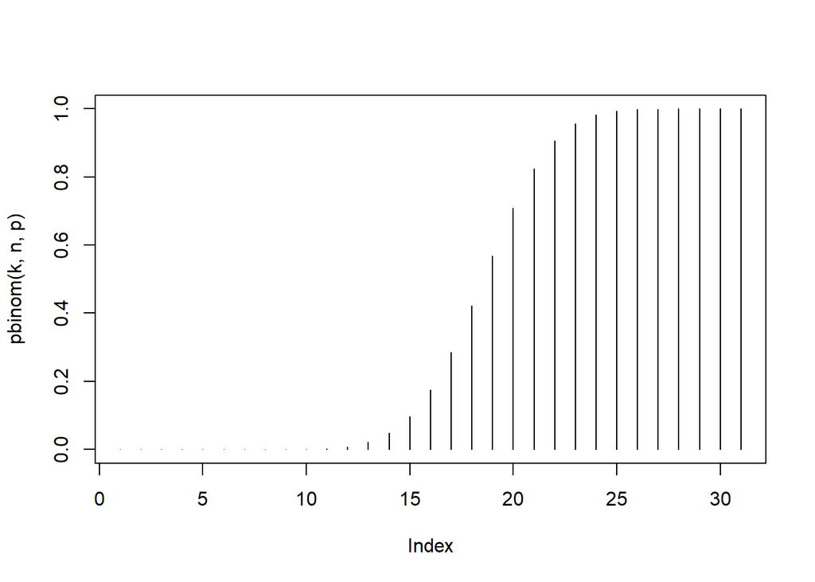

```r
plot(pbinom(k, n, p), type="h")
```

#### Cuantiles

```r
qbinom(0.25, n, p)
```

```
## [1] 16
```

```r
qbinom(0.5, n, p)
```

```
## [1] 18
```

```r
qbinom(0.75, n, p)
```

```
## [1] 20
```

Se puede deducir que están bastante concentrados.

#### Aleatorios

En R

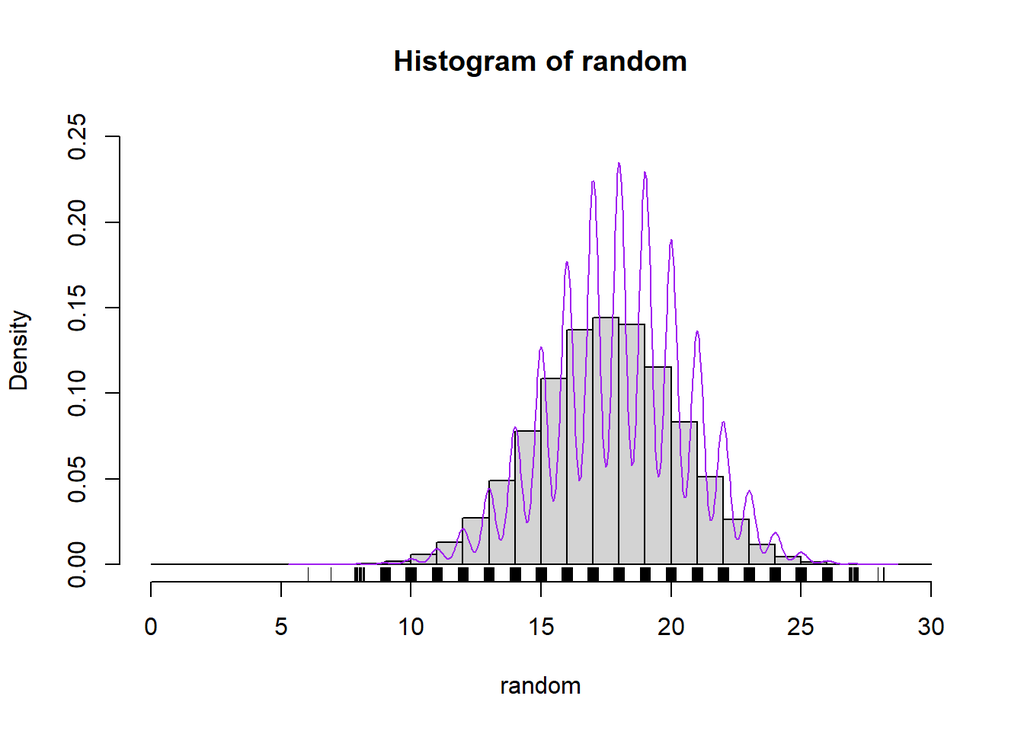

```r
random = rbinom(100000, n, p)
hist(random, breaks=0:n, freq = FALSE, ylim=c(0,0.25))
lines(density(random), col="purple")
rug(jitter(random))
```

**En Python**

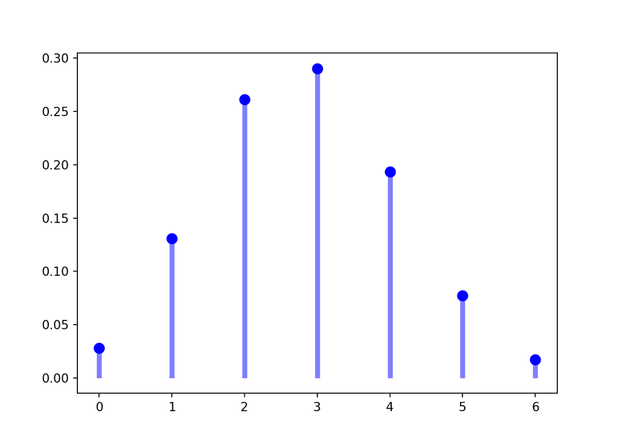

```python
from scipy.stats import binom
import matplotlib.pyplot as plt
import numpy as np

fig, ax = plt.subplots(1,1)
n = 7
p = 0.4

mean, var, skew, kurt = binom.stats(n, p, moments = "mvsk")

x = np.arange(binom.ppf(0.00001,n,p), binom.ppf(0.99999,n,p))

ax.plot(x, binom.pmf(x, n, p), "bo", ms=8,label="Función de densidad de una B(7, 0.4)")
ax.vlines(x, 0, binom.pmf(x,n,p),colors="b", lw=4, alpha=0.5)
plt.show()
```

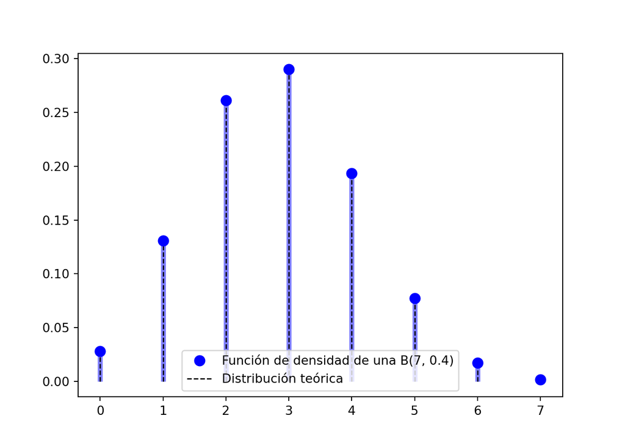

```python
fig, ax = plt.subplots(1,1)
x = np.arange(0,n+1)

ax.plot(x, binom.pmf(x, n, p), "bo", ms=8,label="Función de densidad de una B(7, 0.4)")
ax.vlines(x, 0, binom.pmf(x,n,p),colors="b", lw=4, alpha=0.5)
rv = binom(n,p)
ax.vlines(x,0,rv.pmf(x), colors="k", linestyles="--", lw=1, label="Distribución teórica")
ax.legend(loc="best",frameon=True)
plt.show()
```

```python
print("Media:", mean)
```

```
## Media: 2.8000000000000003
```

```python
print("Varianza:", var)
```

```
## Varianza: 1.6800000000000002
```

```python
print("Sesgo:", skew)
```

```
## Sesgo: 0.15430334996209186
```

```python
print("Curtosis:", kurt)
```

```
## Curtosis: -0.261904761904762
```

**Distribución acumulada**

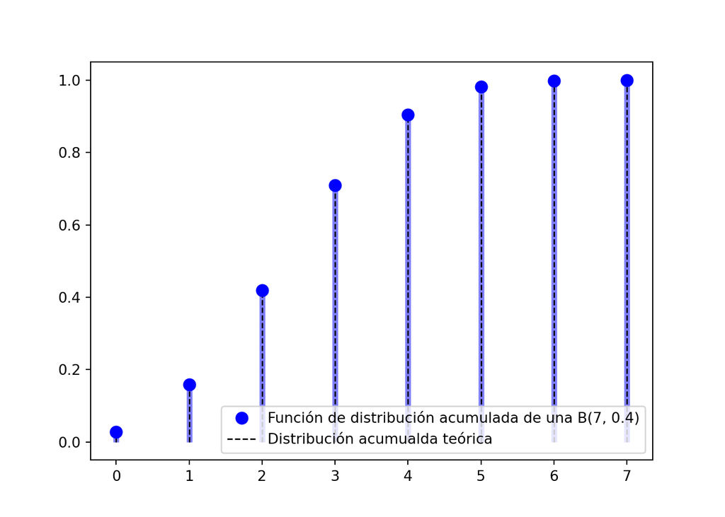

```python
fig, ax = plt.subplots(1,1)
x = np.arange(0,n+1)

ax.plot(x, binom.cdf(x, n, p), "bo", ms=8,label="Función de distribución acumulada de una B(7, 0.4)")
ax.vlines(x, 0, binom.cdf(x,n,p),colors="b", lw=4, alpha=0.5)
rv = binom(n,p)
ax.vlines(x,0,rv.cdf(x), colors="k", linestyles="--", lw=1, label="Distribución acumualda teórica")
ax.legend(loc="best",frameon=True)
plt.show()
```

**Aleatorios**

```python
fix, ax = plt.subplots(1,1)
r = binom.rvs(n = n, p = p, size=10000)
ax.hist(r, bins=n)
```

```
## (array([ 242., 1282., 2657., 2904., 1922.,  795.,  198.]), array([0., 1., 2., 3., 4., 5., 6., 7.]), <BarContainer object of 7 artists>)
```

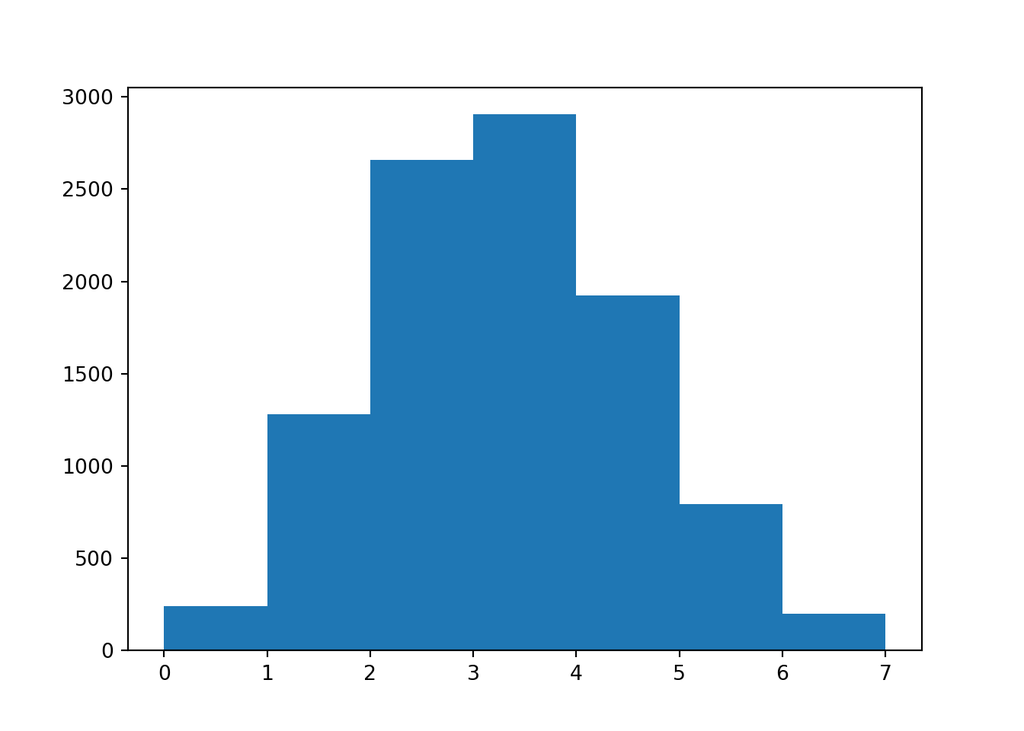

```python
plt.show()
```

**En R**

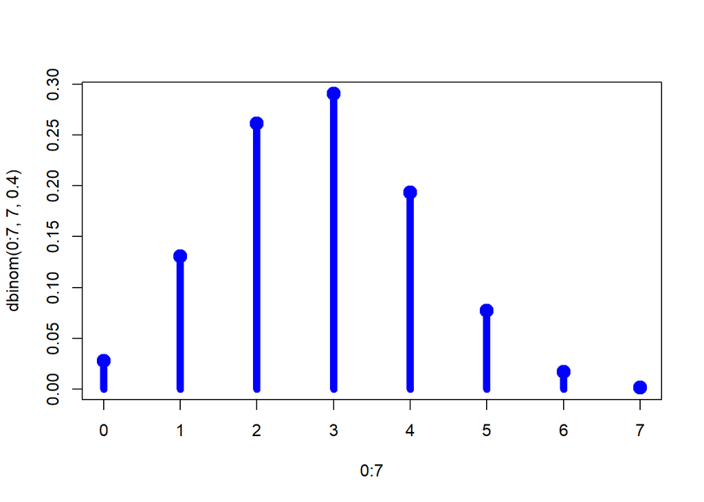

```r
plot(x=0:7, y=dbinom(0:7, 7, 0.4), type="h", col="blue", lwd=7)
points(x=0:7, y=dbinom(0:7, 7, 0.4), lwd=7, col="blue")
```

```r
#curve(dbinom(0:7, 7, 0.4),add = TRUE)
```